# STAT4: RELATION ENTRE VARIABLES QUALITATIVES

Tableau de contingence et test du chi-2

Claude Grasland & Jean-Paul Nguesso

2025-06-01

## Introduction

En simplifiant un peu, voici les différentes étapes que l’on doit suivre pour exploiter un questionnaire

### Etapes

1. le recodage des variables et de leurs modalités
2. la production de tris à plat (analyse d’une variable isolée)
3. la production de tableaux croisés (croisement de deux variables)
4. le test d’hypothèse de relations entre deux variables (test du chi-2)

# 1. PREPARATION DES DONNEES

## 1.1. Chargement des données

On charge un fichier contenant les résultats d’une enquête.

| RESPNO | withinwt_ea | URBRUR | REGION | EA_SVC_A | EA_SVC_B | EA_FAC_B | EA_ROAD_C | THISINT | ADULT_CT | CALLS | Q1 | Q2 | Q46F | Q46G | Q46H | Q46I | Q57A | Q57B | Q58A | Q58C | Q90D | Q90F | Q90G | Q91C | Q92A | Q94 | LENGTH | Q101 | Q102 | … |
| --- | --- | --- | --- | --- | --- | --- | --- | --- | --- | --- | --- | --- | --- | --- | --- | --- | --- | --- | --- | --- | --- | --- | --- | --- | --- | --- | --- | --- | --- | --- |
| CDI1133 | 0.83266906901268 | Urbain | YAMOUSSOUKRO | Oui | Oui | Non | Très bonne | Femme | 2 | 1 | 27 | Français | Plutôt mal | Très mal | Très mal | Plutôt bien | Non | Non | Non | Le vaccin peut causer d’autres effets secondaires indésirables | Oui (en possède personnellement) | Oui (en possède personnellement) | Oui (A accès à l’internet) | Oui, à l’intérieur de la maison | Oui | Université inachevée | 73 | Femme | Noir / Africain | … |
| CDI0105 | 0.890007770199618 | Urbain | ABIDJAN | Oui | Oui | Oui | Très bonne | Femme | 4 | 2 | 52 | Français | Plutôt mal | Plutôt bien | Plutôt bien | Plutôt mal | Oui | Non | Non | Le vaccin n’est pas sûr | Oui (en possède personnellement) | Oui (en possède personnellement) | Oui (A accès à l’internet) | Oui, à l’intérieur de la maison | Oui | Université achevée | 188 | Femme | Noir / Africain | … |
| CDI0045 | 1.11789282426283 | Urbain | ABIDJAN | Oui | Oui | Oui | Très bonne | Homme | 4 | 1 | 21 | Sénoufo | Très bien | Plutôt bien | Plutôt bien | Plutôt bien | Non | Non | Oui | Non applicable | Quelqu’un d’autre dans le ménage en possède | Oui (en possède personnellement) | Oui (A accès à l’internet) | Oui, à l’intérieur de la concession | Oui | Enseignement secondaire / lycée inachevé | 110 | Homme | Noir / Africain | … |
| CDI1087 | 0.882969999920481 | Rural | MARAHOUE | Oui | Non | Oui | Passable | Femme | 4 | 1 | 45 | Gouro | Très mal | Très mal | Très mal | Très mal | Non | Non | Oui | Non applicable | Non. Personne dans le ménage n’en possède | Oui (en possède personnellement) | Non (N’a pas accès à l’internet) | Non, pas disponible | Oui | Enseignement primaire inachevé | 65 | Femme | Noir / Africain | … |
| CDI1036 | 0.96121448550732 | Rural | TCHOLOGO | Non | Non | Oui | Mauvaise | Homme | 1 | 1 | 76 | Sénoufo | Plutôt bien | Plutôt bien | Plutôt bien | Plutôt mal | Non | Oui | Oui | Non applicable | Non. Personne dans le ménage n’en possède | Oui (en possède personnellement) | Non (N’a pas accès à l’internet) | Oui, à l’intérieur de la concession | Non | Pas d’enseignement formel | 130 | Homme | Noir / Africain | … |
| CDI0119 | 1.11789282426283 | Urbain | ABIDJAN | Oui | Oui | Oui | Passable | Homme | 3 | 1 | 66 | Français | Plutôt bien | Très mal | Très mal | Très mal | Non | Non | Oui | Non applicable | Non. Personne dans le ménage n’en possède | Oui (en possède personnellement) | Non (N’a pas accès à l’internet) | Oui, à l’intérieur de la concession | Oui | Enseignement secondaire / lycée inachevé | 137 | Homme | Noir / Africain | … |

## 1.2 Chargement des métadonnées

On charge ensuite un tableau contenant des informations sur les variables et leurs modalités

| code | def |
| --- | --- |
| RESPNO | Numéro du répondant |
| withinwt_ea | Facteur de pondération nationale |
| URBRUR | Type de milieu: Urbain ou Rural |
| REGION | Région |
| EA_SVC_A | EA-SVC-A. Réseau électrique dans la ZD |
| EA_SVC_B | EA-SVC-B. Système d’adduction d’eau dans la ZD |
| EA_FAC_B | EA-FAC-B. École dans la ZD |
| EA_ROAD_C | EA-ROAD-C. État de la route sur les derniers 5km |
| THISINT | Cet entretien, sexe |
| ADULT_CT | Nombre de citoyens adultes dans le ménage |
| CALLS | Nombre de visites |
| Q1 | Q1. Age |
| Q2 | Q2. Langue parlée dans le ménage |
| Q46F | Q46f. Réduction de la criminalité |
| Q46G | Q46g. Amélioration des services de santé de base |
| Q46H | Q46h. Satisfaction des besoins en éducation |
| Q46I | Q46i. Fourniture de services d’eau et d’assainissement |
| Q57A | Q57a. Est tombé malade de la COVID-19 |
| Q57B | Q57b. Perte de revenu à cause de la COVID-19 |
| Q58A | Q58a. A reçu le vaccin contre la COVID-19 |
| Q58C | Q58c. Raison principale pour laquelle il est peu probable de vacciner |
| Q90D | Q90d. Possède ordinateur |
| Q90F | Q90f. Possède téléphone portable |
| Q90G | Q90g. Téléphone a un accès à l’Internet |
| Q91C | Q91c. Emplacement de la toilette ou latrine |
| Q92A | Q92a. Maison raccordée au réseau électrique |
| Q94 | Q94. Niveau d’instruction du répondant |
| LENGTH | Durée de l’entretien |
| Q101 | Q101. Sexe du répondant |
| Q102 | Q102. Race du répondant |
| Q103 | Q103. Langue principale de l’entretien |

## 1.3 Choix de variables à analyser

On sélectionne dans le tableau une variable Y que l’on veut expliquer et des variables X1, X2 …X3 qui peuvent servir à expliquer Y. On décide par exemple d’examiner les variables suivantes :

- vac : A été vacciné contre le covid (Q58A)
- sex : Sexe (Q101)
- age : Age (Q1)
- mil : Milieu Urbain ou rural (URBRUR)
- ins : Niveau d’instruction (Q94)

| vac | sex | age | mil | ins |
| --- | --- | --- | --- | --- |
| Non | Femme | 27 | Urbain | Université inachevée |
| Non | Femme | 52 | Urbain | Université achevée |
| Oui | Homme | 21 | Urbain | Enseignement secondaire / lycée inachevé |
| Oui | Femme | 45 | Rural | Enseignement primaire inachevé |
| Oui | Homme | 76 | Rural | Pas d’enseignement formel |
| Oui | Homme | 66 | Urbain | Enseignement secondaire / lycée inachevé |

## 1.4 Recodage de variables qualitative

On veut simplifier la variable reltive au niveau d’instruction qui possède trop de classes. On commence par examiner la distribution des fréquences

| Var1 | Freq |
| --- | --- |
| A refusé | 1 |
| Enseignement informel seulement (y compris enseignement coranique ) | 36 |
| Enseignement primaire achevé | 85 |
| Enseignement primaire inachevé | 235 |
| Enseignement secondaire / lycée achevé | 94 |
| Enseignement secondaire / lycée inachevé | 402 |
| Ne sait pas | 5 |
| Pas d’enseignement formel | 165 |
| Post universitaire | 2 |
| Qualifications post-secondaires autres qu’universitaires (certificat ou diplôme d’école polytechnique) | 32 |
| Université achevée | 65 |
| Université inachevée | 78 |

## 1.4 Recodage de variables qualitative

Puis on recode chaque niveau afin de n’avoir plus que quatre modalités

| Var1 | Freq |
| --- | --- |
| Inf. | 201 |
| Prim. | 320 |
| Sec. | 496 |
| Sup. | 177 |

## 1.5 Découpage de variables quantitatives

On veut maintenant découper la variable âge en trois classes.

On doit donc choisir de façon judicieuse les classes d’âge.

| Var1 | Freq |
| --- | --- |
| - de 30 ans | 482 |
| 30-50 ans | 559 |
| + de 50 ans | 159 |

## 1.5 Resumé du tableau

On élimine les individus ayant de svaleurs manquantes (6 sur 1200) puis on résume rapidement le tableau:

| **Characteristic** | **N = 1,194**<sup>1</sup> |
| --- | --- |
| vac |  |
| Non | 764 (64%) |
| Oui | 430 (36%) |
| sex |  |
| Femme | 598 (50%) |
| Homme | 596 (50%) |
| mil |  |
| Rural | 542 (45%) |
| Urbain | 652 (55%) |
| ins4 |  |
| Inf. | 201 (17%) |
| Prim. | 320 (27%) |
| Sec. | 496 (42%) |
| Sup. | 177 (15%) |
| age3 |  |
| - de 30 ans | 479 (40%) |
| 30-50 ans | 557 (47%) |
| + de 50 ans | 158 (13%) |

<sup>1</sup> n (%)

# 2. TRI A PLAT

Quelles sont les étapes d’analyse d’une variable qualitative ? On va suivre ici un programme type qui sera ensuite mis en oeuvre avec R

## 2.1 : Analyse de la variable à expliquer (dépendante) Y

On suppose que la variable à expliquer est le fait d’être vacciné

### Fréquence simple

On calcule tout d’abord l’effectif de chaaque modalité

| Var1 | Freq |
| --- | --- |
| Non | 764 |
| Oui | 430 |

## 2.1 : Analyse de la variable à expliquer (dépendante) Y

### Pourcentage

On calcule ensuite la part du total que cela représente en pourcentage

| Var1 | Freq |
| --- | --- |
| Non | 64 |
| Oui | 36 |
| Sum | 100 |

## 2.1 : Analyse de la variable à expliquer (dépendante) Y

On visualise généralement à l’aide d’un diagramme en bâtons :

### Diagramme en bâton

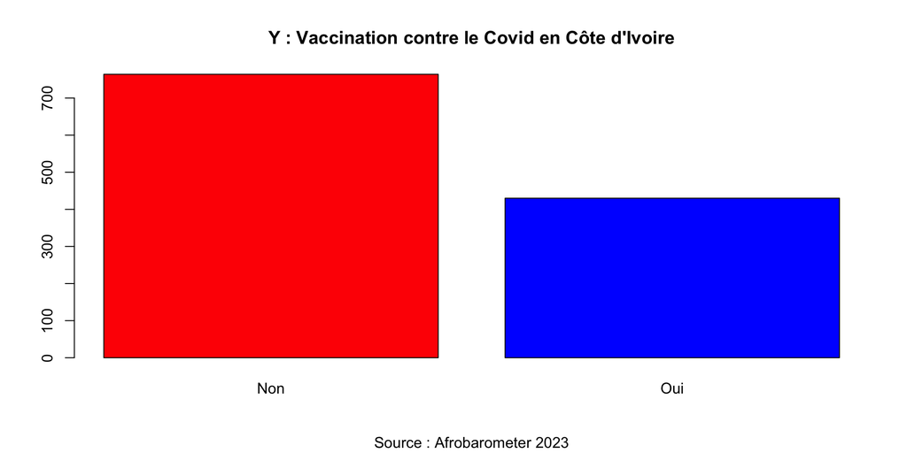

## 2.1 : Analyse de la variable à expliquer (dépendante) Y

### Camembert

On peut également faire un camenbert si on préfère. C’est plus joli mais en fait moins facile à lire.

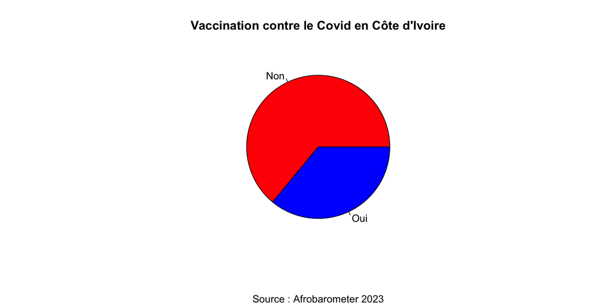

## 2.2 Analyse de la variable explicative (indépendante) X

On suppose que la variable explicative (indépendante) est age3 (âge en trois classes) On reprend les étapes précédentes

### Fréquence simple

Calculer les fréquences de chaque classe

| Var1 | Freq |
| --- | --- |
| - de 30 ans | 479 |
| 30-50 ans | 557 |
| + de 50 ans | 158 |

## 2.2 Analyse de la variable explicative (indépendante) X

### Pourcentage

Calculer les valeurs en pourcentage

| Var1 | Freq |
| --- | --- |
| - de 30 ans | 40.1 |
| 30-50 ans | 46.6 |
| + de 50 ans | 13.2 |
| Sum | 100.0 |

- **Commentaire** : Notre échantillon comporte 40.1% de jeunes, 46.6% d’adultes et 13.2% de vieux.

## 2.2 Analyse de la variable explicative (indépendante) X

### Diagramme en bâton

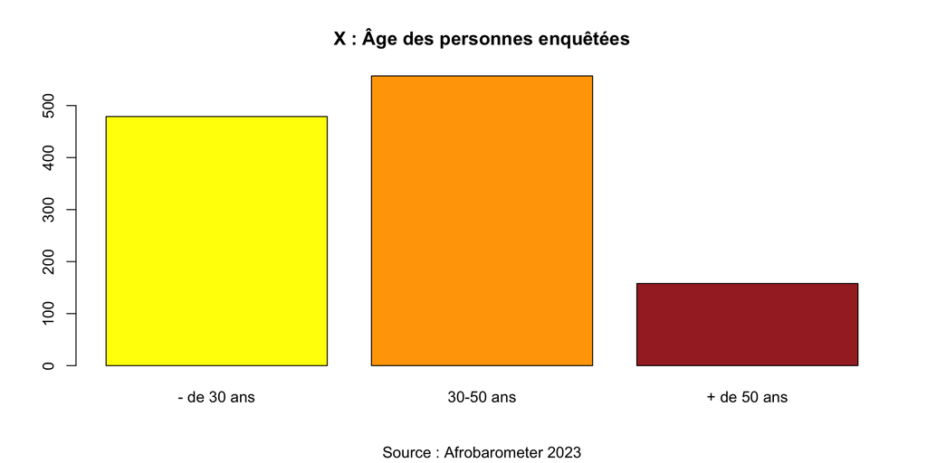

## 2.3 Marge d’erreur

### Quel est le problème ?

- On appelle **tri à plat** l’opération consistant à dénombrer les modalités d’une variable qualitative et à l’exprimer soit en **effectif (nombre de réponses)** soit en **pourcentage (part des réponses).**.
- Les deux opérations paraissent équivalentes mais en réalité elles ne le sont pas car le pourentage seul ne permet pas de retrouvr la **taille de l’échantillon total** sur lequel ce pourcentage a été calculé.
- Or, un pourcentage doit toujours être associé à une **marge d’erreur** qui dépend de la taille de l’échantillon
- **Plus l’échantillon est grand, plus la marge d’erreur sera faible**.

## 2.3 Tri à plat et marge d’erreur

**La marge d’erreur sur un pourcentage** aussi appelée **erreur d’échantillonage** dépend donc de la **taille de l’échantillon** selon la formule suivante

$$E = \sqrt{p(1-p) / n}$$

Nous avons trouvé que **36% des personnes étaient vaccinées** sur un échantillon de 1194 personnes

On a donc p = 0.36, (1-p) = 0.64 et n = 1194, donc

$$E = \sqrt{0.36 * 0.64 / 1194} = 0.014$$

Notre intervalle de confiance à 95% sera alors défini par [p-2E ; p+2E] soit une erreur de + ou - 2.8 points de pourcentage.

- Il est donc pplus juste de dire que le pourcentage de personnes vaccinées est compris **entre 33.2% et 38.8%**

## 2.3 Tri à plat et marge d’erreur

### Calcul de la marge d’erreur

Si vous êtes allergiques aux calculs mathématiques, vous pouvez vous contenter de retenir les valeurs de référence suivantes :

| taille de l’échantillon (n) | Intervalle de confiance (+ ou - ) |
| --- | --- |
| 20 | 22.4 |
| 50 | 14.1 |
| 100 | 10.0 |
| 200 | 7.1 |
| 400 | 5.0 |
| 1000 | 3.2 |
| 1600 | 2.5 |
| 5000 | 1.4 |
| 10000 | 1.0 |

Exemple : pour un sondage sur **1000 personnes**, l’intervalle de confiance correspond au pourcentage observé **plus ou moins 3.2 points**.

# 3. la production de tableaux croisés

Le coeur du travail d’analyse du questionnaire est la réalisation de **tris croisés** c’est-à-dire de **tableaux de contingence** croisant les réponses à deux questions (X et Y).

## 3.1 tableau de contingence

|  | Non | Oui | Sum |
| --- | --- | --- | --- |
| - de 30 ans | 336 | 143 | 479 |
| 30-50 ans | 346 | 211 | 557 |
| + de 50 ans | 82 | 76 | 158 |
| Sum | 764 | 430 | 1194 |

Le tableau de contingence permet de produire différents tableaux de pourcentage.

## 3.2 pourcentage en ligne

|  | Non | Oui | Total |
| --- | --- | --- | --- |
| - de 30 ans | 70.1 | 29.9 | 100 |
| 30-50 ans | 62.1 | 37.9 | 100 |
| + de 50 ans | 51.9 | 48.1 | 100 |
| All | 64.0 | 36.0 | 100 |

## 3.3 pourcentage en colonne

|  | Non | Oui | All |
| --- | --- | --- | --- |
| - de 30 ans | 44.0 | 33.3 | 40.1 |
| 30-50 ans | 45.3 | 49.1 | 46.6 |
| + de 50 ans | 10.7 | 17.7 | 13.2 |
| Total | 100.0 | 100.0 | 100.0 |

**Exemple de lecture** : **33.3%** des personnes qui ont été vaccinés ont moins de 30 ans

# 4. Test du chi-2

## 4.1 Formulation d’une hypothèse H1

Dans le cas de notre exemple on remarque que :

- les jeunes sont les moins vaccinés (30%)
- les adultes sont proches de la moyenne (38%)
- les vieux sont les plus vaccinés (48%)

#### Formulation de l’hypothèse de recherche

**H1: Dans le cas de la population de plus de 18 ans en Côte d’Ivoire en 2021, il existe un lien entre l’âge (X) et le fait d’avoir été vacciné contre le covid (Y).**

## 4.2 Transformation en hypothèse H0

- En statistique, on ne teste jamais directement l’hypothèse H1 (*il y a une relation entre X et Y*) mais on teste l’hypothèse inverse (*il n’y a pas de relation entre X et Y*) qu’on appelle **hypothèse nulle**. Pourquoi cette complication apparente ?
- Parce que l’hypothèse nulle est plus rigoureuse et revient à **se demander si ce n’est pas le hasard qui explique les différence de pourcentage observées**. Dans notre exemple on va donc poser :

#### Formulation de l’hypothèse nulle

**H0 : Il n’y a pas de relation entre l’âge (X) et le fait d’avoir été vacciné contre le Covid (Y).** Les différences de pourcentage que nous avons mises en évidence sont peut-être l’effet du hasard.

## 4.3 Effectifs théoriques

Afin de voir si le hasard est effectivement intervenu, on va reconstituer ce que serait le tableau de contingence croisant X et Y dans le cas où les deux variables ne sont pas reliées.

#### Effectifs observés : Nij et effectifs théoriques Tij = (Ni. x N.j)/N..

|  | Non | Oui | Sum |
| --- | --- | --- | --- |
| - de 30 ans | 336 | 143 | 479 |
| 30-50 ans | 346 | 211 | 557 |
| + de 50 ans | 82 | 76 | 158 |
| Sum | 764 | 430 | 1194 |

|  | Non | Oui | Sum |
| --- | --- | --- | --- |
| - de 30 ans | 306.5 | 172.5 | 479 |
| 30-50 ans | 356.4 | 200.6 | 557 |
| + de 50 ans | 101.1 | 56.9 | 158 |
| Sum | 764.0 | 430.0 | 1194 |

## 4.4 Effectifs résiduels

On va ensuite mesurer les écarts entre effectifs observés et théoriques appelés résidus **(Nij-Tij)** puis les exprimer sous une forme mathématique appelée chi2 définie par la formule **(Nij-Tij)x(Nij-Tij)/Tij**

#### Résidus (Nij-Tij) et Chi-2 = (Nij-Tij)x(Nij-Tij)/Tij

|  | Non | Oui | Sum |
| --- | --- | --- | --- |
| - de 30 ans | 29.5 | -29.5 | 0 |
| 30-50 ans | -10.4 | 10.4 | 0 |
| + de 50 ans | -19.1 | 19.1 | 0 |
| Sum | 0.0 | 0.0 | 0 |

|  | Non | Oui | Sum |
| --- | --- | --- | --- |
| - de 30 ans | 2.8 | 5.0 | 7.9 |
| 30-50 ans | 0.3 | 0.5 | 0.8 |
| + de 50 ans | 3.6 | 6.4 | 10.0 |
| Sum | 6.8 | 12.0 | 18.8 |

## 4.5 Calcul du chi-2

Le **chi-2 total du tableau (18.75)** sera d’autant plus élevé que la distribution observée s’éloigne de la distribution théorique. Plus le chi-2 augmente, moins il y a de chance que le hasard explique les différences entre valeurs observées et estimées. On peut alors **faire un test pour connaître la probabilité que le chi-2 observé soit l’effet du hasard.**

```
    Pearson's Chi-squared test

data:  tab
X-squared = 18.748, df = 2, p-value = 8.488e-05
```

## 4.5 Test du chi-2

- le tableau possède **2 degré de liberté** = (lignes - 1) x (colonnes - 1)
- le tableau possède un **chi-2 égal à 18.75**
- Un calcul effectué par un logiciel de statistique montre que la probabilité que cette valeur soit l’effet du hasard **(p-value)** est de **0.00008** c’est-à-dire moins d’une chance sur 1000

On va donc **rejeter l’hypothèse d’indépendance H0**

## 4.6 Significativité

Pour fixer les ordres de grandeur, voici un tableau simple à retenir :

| Test..p.value. | Interprétation | code |
| --- | --- | --- |
| > 0.10 | Non significatif | n.s |
| 0.05 à 0.10 | Presque significatif | . |
| 0.01 à 0.05 | légèrement significatif | * |
| 0.001 à 0.01 | significatif | ** |
| 0.001 < | très significatif | *** |

## 4.7 Limites du test du chi-2

1. On doit disposer d’un échantillon d’**au moins 20 individus**
2. Toutes les cases du tableau doivent avoir un **effectif théorique >= 5**

Si ces conditions ne sont pas respectées, le test du chi-2 n’est pas valide et R enverra un message d’avertissement ou refusera de faire le calcul.

# 5. AUTRES EXEMPLES

## 5.1 Relation entre vaccination et sexe

Que pensez vous de cette relation ?

Tableau de contingence

|  | Non | Oui | Sum |
| --- | --- | --- | --- |
| Femme | 403 | 195 | 598 |
| Homme | 361 | 235 | 596 |
| Sum | 764 | 430 | 1194 |

% enligne

|  | Non | Oui | Total |
| --- | --- | --- | --- |
| Femme | 67.4 | 32.6 | 100 |
| Homme | 60.6 | 39.4 | 100 |
| All | 64.0 | 36.0 | 100 |

```
    Pearson's Chi-squared test with Yates' continuity correction

data:  tab
X-squared = 5.7341, df = 1, p-value = 0.01664
```

## 5.2 Relation entre vaccination et milieu urbain/rural

Que pensez vous de cette relation ?

Tableau de contingence

|  | Non | Oui | Sum |
| --- | --- | --- | --- |
| Rural | 332 | 210 | 542 |
| Urbain | 432 | 220 | 652 |
| Sum | 764 | 430 | 1194 |

% enligne

|  | Non | Oui | Total |
| --- | --- | --- | --- |
| Rural | 61.3 | 38.7 | 100 |
| Urbain | 66.3 | 33.7 | 100 |
| All | 64.0 | 36.0 | 100 |

```
    Pearson's Chi-squared test with Yates' continuity correction

data:  tab
X-squared = 3.0014, df = 1, p-value = 0.08319
```

## 5.2 Relation entre vaccination et niveau d’instruction

Que pensez vous de cette relation ?

Tableau de contingence

|  | Non | Oui | Sum |
| --- | --- | --- | --- |
| Inf. | 130 | 71 | 201 |
| Prim. | 195 | 125 | 320 |
| Sec. | 318 | 178 | 496 |
| Sup. | 121 | 56 | 177 |
| Sum | 764 | 430 | 1194 |

% enligne

|  | Non | Oui | Total |
| --- | --- | --- | --- |
| Inf. | 64.7 | 35.3 | 100 |
| Prim. | 60.9 | 39.1 | 100 |
| Sec. | 64.1 | 35.9 | 100 |
| Sup. | 68.4 | 31.6 | 100 |
| All | 64.0 | 36.0 | 100 |

```
    Pearson's Chi-squared test

data:  tab
X-squared = 2.8062, df = 3, p-value = 0.4225
```

# 6. QUIZZ

## 6.1 Quelle est la principale utilisation du test du χ²?

- Etudier la liaison entre deux variables qualitatives
- Calculer la variance d’une variable quantitative
- Mesurer la moyenne d’une variable quantitative
- Déterminer la mode d’une distribution

## 6.1 Quelle est la principale utilisation du test du χ²?

- Etudier la liaison entre deux variables qualitatives

## 6.2 Quelle hypothèse nulle correspond au test du χ² d’indépendance?

- Les deux variables ont la même distribution
- Il n’existe pas de liaison entre les deux variables qualitatives
- Les deux variables sont parfaitement liées
- Les deux variables sont indépendantes de la population

## 6.2 Quelle hypothèse nulle correspond au test du χ² d’indépendance?

- Il n’existe pas de liaison entre les deux variables qualitatives

## 6.3 Quelle condition doit être remplie pour appliquer le test du χ²?

- Les effectifs théoriques doivent être supérieurs ou égaux à 5
- Les effectifs observés doivent être inférieurs à 5
- Les effectifs théoriques doivent être inférieurs à 5
- Les effectifs observés doivent être supérieurs à 5

## 6.3 Quelle condition doit être remplie pour appliquer le test du χ²?

- Les effectifs théoriques doivent être supérieurs ou égaux à 5

## 6.4 Que représente un tableau de contingence dans le contexte du test du χ²?

- Un graphique en barres
- Une liste de valeurs numériques simples
- Une distribution de probabilités
- Une matrice qui présente la distribution des fréquences observées entre deux variables

## 6.4 Que représente un tableau de contingence dans le contexte du test du χ²?

- Une matrice qui présente la distribution des fréquences observées entre deux variables

## 6.5 Comment calcule-t-on le degré de liberté pour un test du χ²?

- Nombre de cellules dans le tableau
- Nombre total d’observations
- Nombre de lignes + nombre de colonnes
- (nombre de lignes - 1) × (nombre de colonnes - 1)

## 6.5 Comment calcule-t-on le degré de liberté pour un test du χ²?

- (nombre de lignes - 1) × (nombre de colonnes - 1)

## 6.6 Quelle est la valeur seuil généralement retenue pour la p dans le test du χ²?

- supérieure à 0,05
- supérieure à 0,1
- inférieure à 0,05
- inférieure à 0,01

## 6.6 Quelle est la valeur seuil généralement retenue pour la p dans le test du χ²?

- inférieure à 0,05